# Random Forest

Lisa Skalon

11 июня 2020 г

```r
library(ggplot2)
library(randomForest)
library(MASS)
library(tree)
library(dplyr)
library(tidyr)
library(caret)
library(psych)
```

We are going to analyze open dataset with heart disease data, available at UCI (https://archive.ics.uci.edu/ml/datasets/Heart+Disease). The description of variables:

1. **age**: age in years
2. **sex**: sex (1 = male; 0 = female)
3. **cp**: chest pain type
   - Value 1: typical angina
   - Value 2: atypical angina
   - Value 3: non-anginal pain
   - Value 4: asymptomatic
4. **trestbps** : resting blood pressure (in mm Hg on admission to the hospital)
5. **chol**: serum cholestoral in mg/dl
6. **fbs**: (fasting blood sugar > 120 mg/dl) (1 = true; 0 = false)
7. **restecg**: resting electrocardiographic results
   - Value 0: normal
   - Value 1: having ST-T wave abnormality (T wave inversions and/or ST elevation or depression of > 0.05 mV)
   - Value 2: showing probable or definite left ventricular hypertrophy by Estes' criteria
8. **thalach**: maximum heart rate achieved
9. **exang**: exercise induced angina (1 = yes; 0 = no)
10. **oldpeak**: ST depression induced by exercise relative to rest
11. **slope**: the slope of the peak exercise ST segment
    - Value 1: upsloping
    - Value 2: flat
    - Value 3: downsloping
12. **ca**: number of major vessels (0-3) colored by flourosopy
13. **thal**: 3 = normal; 6 = fixed defect; 7 = reversable defect
14. **num**: 0 = no heart disease, > 0 = heart disease

The variable wich we are going to predict is **num** - the presence or the absence of heart disease.

We will use randomForest algorithm - algorithm which works by aggregating the predictions made by multiple decision trees of varying depth. Every decision tree in the forest is trained on a subset of the dataset called the bootstrapped dataset.

```r
# read df
df <- read.csv("https://archive.ics.uci.edu/ml/machine-learning-databases/heart-disease/processed.cleveland.data",header=FALSE, na.strings = '?')
names(df) <- c( "age", "sex", "cp", "trestbps", "chol","fbs", "restecg",
                   "thalach","exang", "oldpeak","slope", "ca", "thal", "num")

# deal with na
str(df)
```

```
## 'data.frame':    303 obs. of  14 variables:
##  $ age     : num  63 67 67 37 41 56 62 57 63 53 ...
##  $ sex     : num  1 1 1 1 0 1 0 0 1 1 ...
##  $ cp      : num  1 4 4 3 2 2 4 4 4 4 ...
##  $ trestbps: num  145 160 120 130 130 120 140 120 130 140 ...
##  $ chol    : num  233 286 229 250 204 236 268 354 254 203 ...
##  $ fbs     : num  1 0 0 0 0 0 0 0 0 1 ...
##  $ restecg : num  2 2 2 0 2 0 2 0 2 2 ...
##  $ thalach : num  150 108 129 187 172 178 160 163 147 155 ...
##  $ exang   : num  0 1 1 0 0 0 0 1 0 1 ...
##  $ oldpeak : num  2.3 1.5 2.6 3.5 1.4 0.8 3.6 0.6 1.4 3.1 ...
##  $ slope   : num  3 2 2 3 1 1 3 1 2 3 ...
##  $ ca      : num  0 3 2 0 0 0 2 0 1 0 ...
##  $ thal    : num  6 3 7 3 3 3 3 3 7 7 ...
##  $ num     : int  0 2 1 0 0 0 3 0 2 1 ...
```

```r
sum(is.na(df))
```

```
## [1] 6
```

```r
df <- drop_na(df)

# change num to binary as in the description
df$num[df$num > 0] <- 1


# change data types
df <- transform(df, trestbps = as.factor(sex), cp = as.factor(cp), fbs = as.factor(fbs),
                exang = as.factor(exang), restecg = as.factor(restecg),
                slope = as.factor(slope), ca = as.factor(ca), thal=as.factor(thal),
                sex = as.factor(sex), num=as.factor(num))


summary(df)
```

```
##       age        sex     cp      trestbps      chol       fbs     restecg
##  Min.   :29.00   0: 96   1: 23   0: 96    Min.   :126.0   0:254   0:147
##  1st Qu.:48.00   1:201   2: 49   1:201    1st Qu.:211.0   1: 43   1:  4
##  Median :56.00           3: 83            Median :243.0           2:146
##  Mean   :54.54           4:142            Mean   :247.4
##  3rd Qu.:61.00                            3rd Qu.:276.0
##  Max.   :77.00                            Max.   :564.0
##     thalach      exang      oldpeak      slope   ca      thal    num
##  Min.   : 71.0   0:200   Min.   :0.000   1:139   0:174   3:164   0:160
##  1st Qu.:133.0   1: 97   1st Qu.:0.000   2:137   1: 65   6: 18   1:137
##  Median :153.0           Median :0.800   3: 21   2: 38   7:115
##  Mean   :149.6           Mean   :1.056           3: 20
##  3rd Qu.:166.0           3rd Qu.:1.600
##  Max.   :202.0           Max.   :6.200
```

```r
# check the number of diseased/healthy obs
table(df$num)
```

```
##
##   0   1
## 160 137
```

We divide the dataset 50/50 (train-test split)

```r
set.seed(42)
sample <- sample.int(n=  nrow(df), size = floor(.5*nrow(df)), replace = F)
train <- df[sample,]
test <- df[-sample,]
```

First we run RF with basic parameters (mtry 3, ntree 500)

```r
fit <- randomForest(num ~ ., data = train, importance = T)
fit
```

```
##
## Call:
##  randomForest(formula = num ~ ., data = train, importance = T)
##                Type of random forest: classification
##                      Number of trees: 500
## No. of variables tried at each split: 3
##
##         OOB estimate of  error rate: 17.57%
## Confusion matrix:
##    0  1 class.error
## 0 58 14   0.1944444
## 1 12 64   0.1578947
```

We can check the importance of each feature

```r
importance(fit)
```

```
##                   0         1 MeanDecreaseAccuracy MeanDecreaseGini
## age      14.8089810  9.574592            15.838240        9.3758077
## sex       7.8435348  1.298506             6.642163        1.4835642
## cp       14.4619841 14.099231            18.318179       10.6095090
## trestbps  7.0115333  2.556693             6.914512        1.7498884
## chol      1.9941211  1.904328             2.452581        5.9997134
## fbs      -0.2719562 -2.273344            -1.569159        0.7116747
## restecg   1.8196997  3.476304             3.469078        1.5527951
## thalach   8.0886946 13.266171            14.394343       11.3245792
## exang     0.3261426  6.028456             4.873386        1.8234367
## oldpeak   1.1362873  4.348030             3.913843        5.4338251
## slope     3.8699134  5.035299             6.251089        3.7171380
## ca       16.1770447 14.303537            19.655888        8.0175218
## thal     14.3260000 13.861635            18.061538       10.6032061
```

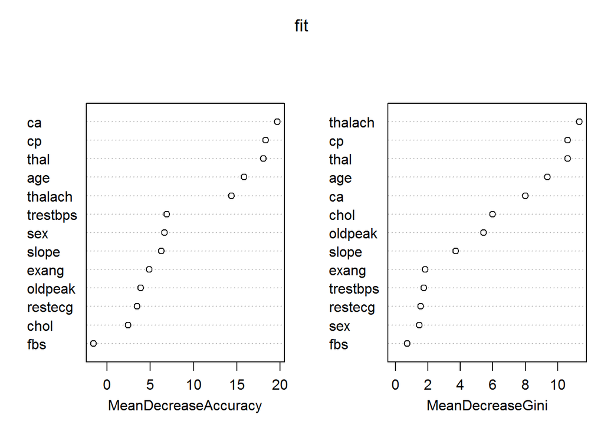

```r
varImpPlot(fit)
```

Let`s predict values in test dataset

```r
pred <- predict(fit, newdata = test[-14])
confusionMatrix(pred, test$num)
```

```
## Confusion Matrix and Statistics
##
##           Reference
## Prediction  0  1
##          0 70 13
##          1 18 48
##
##                Accuracy : 0.7919
##                  95% CI : (0.7179, 0.854)
##     No Information Rate : 0.5906
##     P-Value [Acc > NIR] : 1.525e-07
##
##                   Kappa : 0.5751
##
##  Mcnemar's Test P-Value : 0.4725
##
##             Sensitivity : 0.7955
##             Specificity : 0.7869
##          Pos Pred Value : 0.8434
##          Neg Pred Value : 0.7273
##              Prevalence : 0.5906
##          Detection Rate : 0.4698
##    Detection Prevalence : 0.5570
##       Balanced Accuracy : 0.7912
##
##        'Positive' Class : 0
##
```

We can tune mtry hyperparameter - number of variables randomly sampled as candidates of each split. We also can tune number of trees (manually).

We will tune mtry using cross-validation and caret package

```r
control <- trainControl(method = "cv",
                        number = 10)
rf_tune <- train(num ~ ., data = df, method = "rf", metric= 'Accuracy',
               tuneLength=15, trControl=control)
print(rf_tune)
```

```
## Random Forest
##
## 297 samples
##  13 predictor
##   2 classes: '0', '1'
##
## No pre-processing
## Resampling: Cross-Validated (10 fold)
## Summary of sample sizes: 267, 267, 267, 268, 267, 267, ...
## Resampling results across tuning parameters:
##
##   mtry  Accuracy   Kappa
##    2    0.8180460  0.6322535
##    3    0.8147126  0.6267946
##    4    0.8047126  0.6058139
##    5    0.8113793  0.6194346
##    7    0.7979310  0.5923026
##    8    0.8013793  0.5994486
##    9    0.7911494  0.5780919
##   11    0.8014943  0.5993356
##   12    0.7947126  0.5852041
##   13    0.8080460  0.6121179
##   14    0.7947126  0.5850412
##   16    0.7947126  0.5852780
##   17    0.7880460  0.5712888
##   18    0.7981609  0.5920731
##   20    0.7849425  0.5660351
##
## Accuracy was used to select the optimal model using the largest value.
## The final value used for the model was mtry = 2.
```

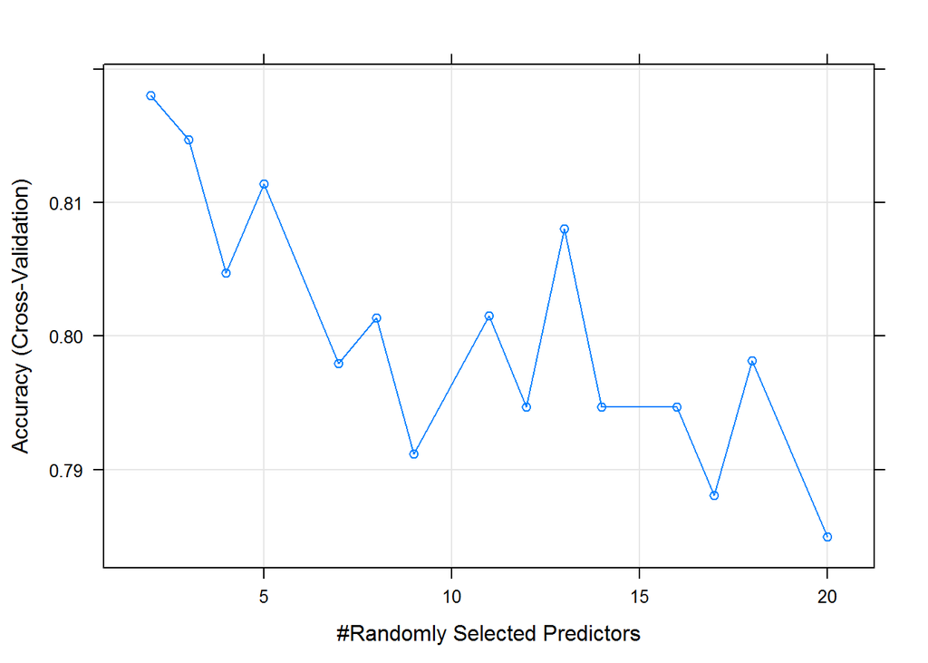

```r
plot(rf_tune)
```

The best mtry = 2

```r
fit2 <- randomForest(num ~ ., data = train,
                    mtry = 2, importance = T)
fit2
```

```
##
## Call:
##  randomForest(formula = num ~ ., data = train, mtry = 2, importance = T)
##                Type of random forest: classification
##                      Number of trees: 500
## No. of variables tried at each split: 2
##
##         OOB estimate of  error rate: 15.54%
## Confusion matrix:
##    0  1 class.error
## 0 60 12   0.1666667
## 1 11 65   0.1447368
```

```r
pred2 <- predict(fit2, newdata = test[-14])
confusionMatrix(pred2, test$num)
```

```
## Confusion Matrix and Statistics
##
##           Reference
## Prediction  0  1
##          0 69 15
##          1 19 46
##
##                Accuracy : 0.7718
##                  95% CI : (0.696, 0.8365)
##     No Information Rate : 0.5906
##     P-Value [Acc > NIR] : 2.439e-06
##
##                   Kappa : 0.5328
##
##  Mcnemar's Test P-Value : 0.6069
##
##             Sensitivity : 0.7841
##             Specificity : 0.7541
##          Pos Pred Value : 0.8214
##          Neg Pred Value : 0.7077
##              Prevalence : 0.5906
##          Detection Rate : 0.4631
##    Detection Prevalence : 0.5638
##       Balanced Accuracy : 0.7691
##
##        'Positive' Class : 0
##
```

```r
importance(fit2)
```

```
##                   0          1 MeanDecreaseAccuracy MeanDecreaseGini
## age      12.9915937  9.2520867            14.009562        9.1269420
## sex       7.3697439  3.5789742             7.321758        1.8430151
## cp       13.8555436 12.4653001            17.185141       10.1736431
## trestbps  7.5531231  2.8442362             7.132258        1.8300902
## chol      3.1146677  0.2718583             2.814922        5.4687231
## fbs       0.3773193 -2.1276268            -1.058044        0.7528984
## restecg   3.8354560  4.3695297             5.598892        1.9660423
## thalach   8.3482809 10.7525786            11.961155       10.5344363
## exang     4.5093052  6.4617627             7.235193        2.4171395
## oldpeak   4.1445034  3.8897908             5.496885        5.6394832
## slope     5.1255111  6.1684356             8.242418        3.8491071
## ca       14.6180366 11.8913237            16.295581        7.2502635
## thal     11.9043851 10.5741476            14.629345        8.2945177
```

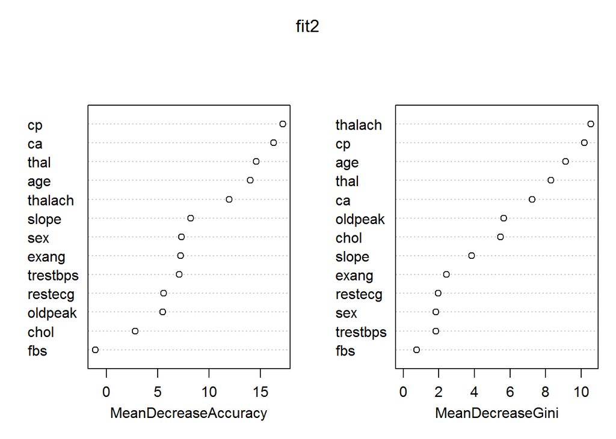

```r
varImpPlot(fit2)
```

We also can tune mtry with basic randomForest function tuneRF, but the resultis the same

```r
mtry_best = tuneRF(df[-14], df$num)
```

```
## mtry = 3  OOB error = 19.53%
## Searching left ...
## mtry = 2     OOB error = 18.52%
## 0.05172414 0.05
## mtry = 1     OOB error = 19.19%
## -0.03636364 0.05
## Searching right ...
## mtry = 6     OOB error = 20.54%
## -0.1090909 0.05
```

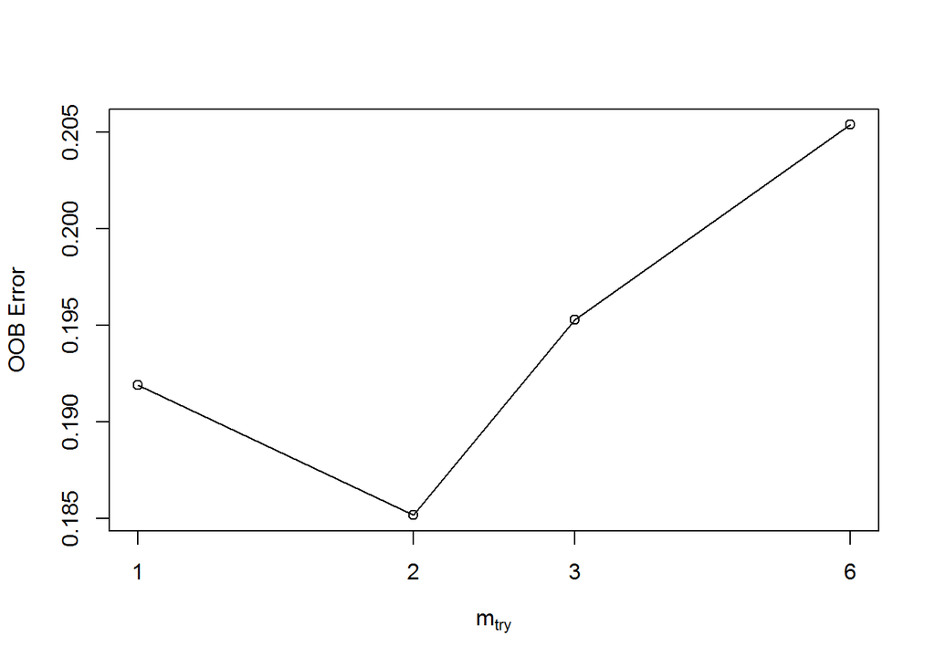

```r
print(mtry_best)
```

```
##       mtry  OOBError
## 1.OOB    1 0.1919192
## 2.OOB    2 0.1851852
## 3.OOB    3 0.1952862
## 6.OOB    6 0.2053872
```

Now we will try to use feture selection and tune mtry for feature selected df

```r
mtry_best = tuneRF(df[, c("cp", "thal", "age", "thalach", "oldpeak")], df$num)
```

```
## mtry = 2  OOB error = 24.24%
## Searching left ...
## mtry = 1     OOB error = 24.58%
## -0.01388889 0.05
## Searching right ...
## mtry = 4     OOB error = 24.92%
## -0.02777778 0.05
```

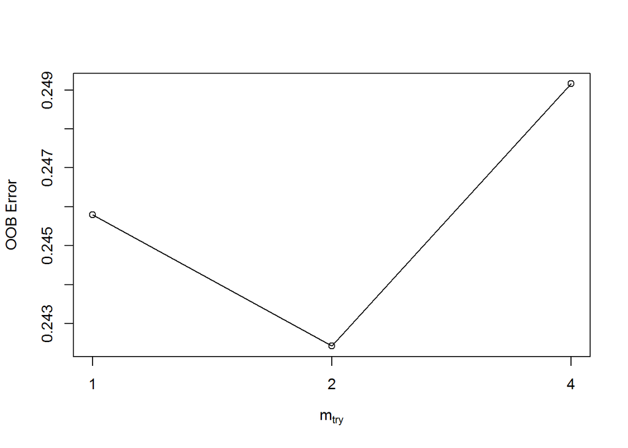

```r
train_best <- train[,c("cp", "thal", "age", "thalach", "oldpeak", "num")]
fit_best <- randomForest(num ~ ., data=train_best,
                    mtry = 2, importance = T)
fit_best
```

```
##
## Call:
##  randomForest(formula = num ~ ., data = train_best, mtry = 2,      importance = T)
##                Type of random forest: classification
##                      Number of trees: 500
## No. of variables tried at each split: 2
##
##         OOB estimate of  error rate: 22.3%
## Confusion matrix:
##    0  1 class.error
## 0 57 15   0.2083333
## 1 18 58   0.2368421
```

```r
pred_best <- predict(fit_best, newdata = test[-14])
confusionMatrix(pred_best, test$num)
```

```
## Confusion Matrix and Statistics
##
##           Reference
## Prediction  0  1
##          0 60 14
##          1 28 47
##
##                Accuracy : 0.7181
##                  95% CI : (0.6387, 0.7887)
##     No Information Rate : 0.5906
##     P-Value [Acc > NIR] : 0.0008347
##
##                   Kappa : 0.4369
##
##  Mcnemar's Test P-Value : 0.0448623
##
##             Sensitivity : 0.6818
##             Specificity : 0.7705
##          Pos Pred Value : 0.8108
##          Neg Pred Value : 0.6267
##              Prevalence : 0.5906
##          Detection Rate : 0.4027
##    Detection Prevalence : 0.4966
##       Balanced Accuracy : 0.7262
##
##        'Positive' Class : 0
##
```

We also can adjust ntree.

```r
fit_n <- randomForest(num ~ ., data = train,
                    mtry = 2, ntree = 2000, importance = T)
fit_n
```

```
##
## Call:
##  randomForest(formula = num ~ ., data = train, mtry = 2, ntree = 2000,      importance = T)
##                Type of random forest: classification
##                      Number of trees: 2000
## No. of variables tried at each split: 2
##
##         OOB estimate of  error rate: 16.22%
## Confusion matrix:
##    0  1 class.error
## 0 58 14   0.1944444
## 1 10 66   0.1315789
```

```r
pred_n <- predict(fit_n, newdata = test[-14])
confusionMatrix(pred_n, test$num)
```

```
## Confusion Matrix and Statistics
##
##           Reference
## Prediction  0  1
##          0 70 12
##          1 18 49
##
##                Accuracy : 0.7987
##                  95% CI : (0.7252, 0.8598)
##     No Information Rate : 0.5906
##     P-Value [Acc > NIR] : 5.604e-08
##
##                   Kappa : 0.5898
##
##  Mcnemar's Test P-Value : 0.3613
##
##             Sensitivity : 0.7955
##             Specificity : 0.8033
##          Pos Pred Value : 0.8537
##          Neg Pred Value : 0.7313
##              Prevalence : 0.5906
##          Detection Rate : 0.4698
##    Detection Prevalence : 0.5503
##       Balanced Accuracy : 0.7994
##
##        'Positive' Class : 0
##
```